# Анализ пользовательского поведения в мобильном приложении

#### Описание проекта

Стартап продаёт продукты питания. Стоит задача: понять, как ведут себя клиенты мобильного приложения.

Изучить воронку продаж: сколько пользователей и как они доходят до покупки. Посмотреть на результаты A/A/B-эксперимента и помочь принять решение о том какой шрифт на сайте лучше. Всех людей поделили на три группы: две контрольные со старыми шрифтами и одну экспериментальную — с новыми. Если 2 контрольные группы равны — можно быть уверенными в проведенном тесте, в ином случае это поможет найти факторы, искозившие результаты.

Записи в таблице — это действия пользователей. Столбцы: название события, уникальный идентификатор пользователя, время события, номер эксперимента: 248 — экспериментальная группа, 246 и 247 — контрольные.

## Шаг 1. Изучение общей информации

```python
import warnings
warnings.filterwarnings("ignore")

import pandas as pd
import numpy as np
import matplotlib.pyplot as plt
import seaborn as sns
import math as mth
from scipy import stats as st
import datetime as dt
import plotly.express as px
from plotly import graph_objects as go

from pylab import rcParams
rcParams['figure.figsize'] = 12, 8

pd.options.mode.chained_assignment = None

#здесь мы загружаем датасет из csv в pandas, но т.к. они защищены соглашением о неразглашении, перезапуск этого процесса не доступен
#logs = pd.read_csv('datasets/logs_exp.csv', sep='\t')

logs.head(3)
```

|  | EventName | DeviceIDHash | EventTimestamp | ExpId |
| --- | --- | --- | --- | --- |
| 0 | MainScreenAppear | 4575588528974610257 | 1564029816 | 246 |
| 1 | MainScreenAppear | 7416695313311560658 | 1564053102 | 246 |
| 2 | PaymentScreenSuccessful | 3518123091307005509 | 1564054127 | 248 |

Столбцы переименовать, а 'event_time' - надо перевести в дату и время

```python
logs.info()
```

```
<class 'pandas.core.frame.DataFrame'>
RangeIndex: 244126 entries, 0 to 244125
Data columns (total 4 columns):
 #   Column          Non-Null Count   Dtype
---  ------          --------------   -----
 0   EventName       244126 non-null  object
 1   DeviceIDHash    244126 non-null  int64
 2   EventTimestamp  244126 non-null  int64
 3   ExpId           244126 non-null  int64
dtypes: int64(3), object(1)
memory usage: 7.5+ MB
```

Пустых ячеек нет, DeviceIDHash и ExpId можно перевести в object type, т.к. эти числа можно считать названиями

```python
logs.describe()
```

|  | DeviceIDHash | EventTimestamp | ExpId |
| --- | --- | --- | --- |
| count | 2.441260e+05 | 2.441260e+05 | 244126.000000 |
| mean | 4.627568e+18 | 1.564914e+09 | 247.022296 |
| std | 2.642425e+18 | 1.771343e+05 | 0.824434 |
| min | 6.888747e+15 | 1.564030e+09 | 246.000000 |
| 25% | 2.372212e+18 | 1.564757e+09 | 246.000000 |
| 50% | 4.623192e+18 | 1.564919e+09 | 247.000000 |
| 75% | 6.932517e+18 | 1.565075e+09 | 248.000000 |
| max | 9.222603e+18 | 1.565213e+09 | 248.000000 |

Здесь уже заметно, что есть 3 группы и в 246 и 248 - как минимум по 25% значений

## Шаг 2. Подготовка данных

```python
logs.columns = ['event_name', 'device_id', 'event_time', 'exp_id']
logs.head(3)
```

|  | event_name | device_id | event_time | exp_id |
| --- | --- | --- | --- | --- |
| 0 | MainScreenAppear | 4575588528974610257 | 1564029816 | 246 |
| 1 | MainScreenAppear | 7416695313311560658 | 1564053102 | 246 |
| 2 | PaymentScreenSuccessful | 3518123091307005509 | 1564054127 | 248 |

```python
logs[['device_id', 'exp_id']] = logs[['device_id', 'exp_id']].astype('str')
logs['event_time'] = pd.to_datetime(logs['event_time'],unit='s')
logs.info()
```

```
<class 'pandas.core.frame.DataFrame'>
RangeIndex: 244126 entries, 0 to 244125
Data columns (total 4 columns):
 #   Column      Non-Null Count   Dtype
---  ------      --------------   -----
 0   event_name  244126 non-null  object
 1   device_id   244126 non-null  object
 2   event_time  244126 non-null  datetime64[ns]
 3   exp_id      244126 non-null  object
dtypes: datetime64[ns](1), object(3)
memory usage: 7.5+ MB
```

```python
logs.head(3)
```

|  | event_name | device_id | event_time | exp_id |
| --- | --- | --- | --- | --- |
| 0 | MainScreenAppear | 4575588528974610257 | 2019-07-25 04:43:36 | 246 |
| 1 | MainScreenAppear | 7416695313311560658 | 2019-07-25 11:11:42 | 246 |
| 2 | PaymentScreenSuccessful | 3518123091307005509 | 2019-07-25 11:28:47 | 248 |

Дубли:

```python
logs.duplicated().value_counts()
```

```
False    243713
True        413
dtype: int64
```

413 дубликатов - удаляем

```python
logs = logs.drop_duplicates()
logs.duplicated().value_counts()
```

```
False    243713
dtype: int64
```

Исправлений совсем не много, можно сказать, в основном "косметические". Таблица готова к исследованию.

## Шаг 3. Изучение и проверка данных

Ответы на вопросы помогут детальнее понять с какими данными мы работаем

### Сколько всего событий в логе?

```python
logs['event_time'].count()
```

```
243713
```

Почти четверть миллиона, хороший датасет

### Сколько всего пользователей в логе?

```python
logs['device_id'].nunique()
```

```
7551
```

Довольно много пользователей для исследования, это хорошо

### Сколько в среднем событий приходится на пользователя?

```python
round(logs.groupby('device_id')['event_time'].count().mean())
```

```
32
```

32 события, при том, что уникальных событий всего 5, это всё из-за главного экрана

### Данными за какой период вы располагаете?

```python
print("данные за {}, от {} до {}".format(logs['event_time'].max()-logs['event_time'].min(), logs['event_time'].min(), logs['event_time'].max()))
```

```
данные за 13 days 16:31:41, от 2019-07-25 04:43:36 до 2019-08-07 21:15:17
```

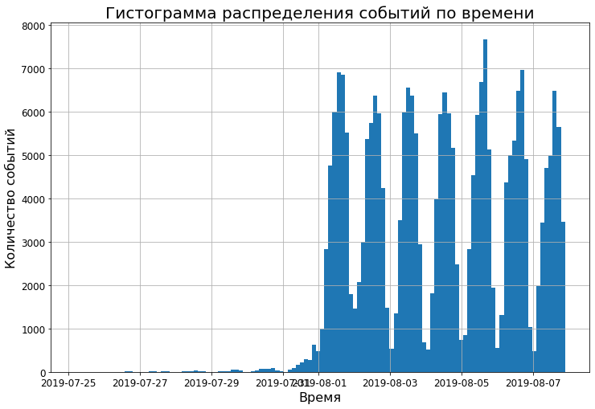

```python
logs['event_time'].hist(bins=120)
plt.title('Гистограмма распределения событий по времени', fontsize=20)
plt.tick_params(labelsize=12)
plt.ylabel('Количество событий',fontsize=16)
plt.xlabel('Время',fontsize=16)
plt.show()
```

Т.е. в реальности тест начался с 1 августа 2019, а не с даты первого события в датасете. На графике видно как данные прыгают изо дня в день.

### Много ли событий и пользователей вы потеряли, отбросив старые данные?

Отбросим всё, что до 1 августа

```python
new_logs = logs[logs['event_time'] > '2019-08-01']
new_logs['event_time'].count()
```

```
240887
```

```python
print('После отсечения мы потеряли всего', round(abs((new_logs['event_time'].count() / logs['event_time'].count())-1),2), '% пользователей')
```

[output not shown]

### Проверьте, что у вас есть пользователи из всех трёх экспериментальных групп

```python
new_logs.groupby('exp_id')['device_id'].nunique()
```

```
exp_id
246    2484
247    2513
248    2537
Name: device_id, dtype: int64
```

Все хорошо, во всех группах есть пользователи

## Шаг 4. Изучение воронки событий

Ответы на вопросы, помогут изучить воронку детально, приступим

### Посмотрите, какие события есть в логах, как часто они встречаются

```python
print(new_logs['event_name'].unique()[1], '- Главный экран')
print()
print(new_logs['event_name'].unique()[4], '- Экран успешной оплаты')
print()
print(new_logs['event_name'].unique()[3], '- Экран карточки')
print()
print(new_logs['event_name'].unique()[2], '- Экран предложения (офера)')
print()
print(new_logs['event_name'].unique()[0], '- Обучение')
```

```
MainScreenAppear - Главный экран

PaymentScreenSuccessful - Экран успешной оплаты

CartScreenAppear - Экран карточки

OffersScreenAppear - Экран предложения (офера)

Tutorial - Обучение
```

```python
new_logs.groupby('event_name')['event_time'].count().sort_values(ascending=False)
```

```
event_name
MainScreenAppear           117328
OffersScreenAppear          46333
CartScreenAppear            42303
PaymentScreenSuccessful     33918
Tutorial                     1005
Name: event_time, dtype: int64
```

Наиболее частое событие "Jnrhsnbt главного экрана", а наиболее редкое - "Обучение". Видимо не так уж и сложно разобраться и без обучения

### Посчитайте, сколько пользователей совершали каждое из этих событий

```python
(new_logs.groupby('device_id')['event_name'] # группируем по пользователям
 .nunique() # считаем количество уникальных событий на пользователя
 .reset_index()
 .query('event_name == 5')['event_name'] # оставляем только тех, у кого все 5 уникальных событий
 .count() # считаем их количество
)
```

```
466
```

Каждое из действий, включая обучение, совершали 466 человек. Теперь посмотрим сколько совершали каждое из действий по отдельности

```python
users_by_events = new_logs.groupby('event_name')['device_id'].nunique().sort_values(ascending=False)
users_by_events
```

```
event_name
MainScreenAppear           7419
OffersScreenAppear         4593
CartScreenAppear           3734
PaymentScreenSuccessful    3539
Tutorial                    840
Name: device_id, dtype: int64
```

И подсчитаем долю от всех уникальных пользователей

```python
for i in users_by_events.index:
    print(i,'-', users_by_events[i], 'пользователей и это', round((users_by_events[i]/new_logs['device_id'].nunique()*100),2),'% от всех пользователей')
```

```
MainScreenAppear - 7419 пользователей и это 98.47 % от всех пользователей
OffersScreenAppear - 4593 пользователей и это 60.96 % от всех пользователей
CartScreenAppear - 3734 пользователей и это 49.56 % от всех пользователей
PaymentScreenSuccessful - 3539 пользователей и это 46.97 % от всех пользователей
Tutorial - 840 пользователей и это 11.15 % от всех пользователей
```

Удивительно, что не все увидели главный экран, возможно эти люди лишь прошли обучение и закрыли

### Предположите, в каком порядке происходят события

Учитывая таблицу ниже, первые 4 события являются воронкой (Главный экран->Оффер->Карточка->Оплата прошла), а вот событие "Обучение" - необязательно, его могут проходить как до покупки так и после.

```python
sales_funnel = new_logs[new_logs['event_name'] != 'Tutorial'].groupby('event_name')['device_id'].nunique().sort_values(ascending=False).reset_index()
sales_funnel
```

|  | event_name | device_id |
| --- | --- | --- |
| 0 | MainScreenAppear | 7419 |
| 1 | OffersScreenAppear | 4593 |
| 2 | CartScreenAppear | 3734 |
| 3 | PaymentScreenSuccessful | 3539 |

```python
from plotly import graph_objects as go

fig = go.Figure(go.Funnel(
    y = ["MainScreenAppear","OffersScreenAppear", "CartScreenAppear", "PaymentScreenSuccessful"],
    x = [7419, 4593,  3734, 3539]
    ))
fig.show()
```

[interactive chart not shown]

Воронка показывает какое количество пользователей переходит из предыдущего шага в следующий. Большая чать теряется на переходе с первого на второй шаг, наже будет подсчитан % потери

### По воронке событий посчитайте, какая доля пользователей проходит на следующий шаг воронки

```python
sales_funnel['conversion'] = 0
sales_funnel.loc[sales_funnel['event_name'] == 'OffersScreenAppear', 'conversion'] = round(((sales_funnel['device_id'][1] / sales_funnel['device_id'][0])*100),2)
sales_funnel.loc[sales_funnel['event_name'] == 'CartScreenAppear', 'conversion'] = round(((sales_funnel['device_id'][2] / sales_funnel['device_id'][1])*100),2)
sales_funnel.loc[sales_funnel['event_name'] == 'PaymentScreenSuccessful', 'conversion'] = round(((sales_funnel['device_id'][3] / sales_funnel['device_id'][2])*100),2)
sales_funnel
```

|  | event_name | device_id | conversion |
| --- | --- | --- | --- |
| 0 | MainScreenAppear | 7419 | 0.00 |
| 1 | OffersScreenAppear | 4593 | 61.91 |
| 2 | CartScreenAppear | 3734 | 81.30 |
| 3 | PaymentScreenSuccessful | 3539 | 94.78 |

### На каком шаге теряете больше всего пользователей?

```python
print('Больше всего теряются при переходе с первого шага на второй:', 100-61.91, '%')
```

```
Больше всего теряются при переходе с первого шага на второй: 38.09 %
```

### Какая доля пользователей доходит от первого события до оплаты?

```python
print('От первого шага до последнего доходят', round(((sales_funnel['device_id'][3] / sales_funnel['device_id'][0])*100),2), '% посетителей')
```

```
От первого шага до последнего доходят 47.7 % посетителей
```

## Шаг 5. Изучение результатов эксперимента

Отвесты на ключевые вопросы проекта

### Сколько пользователей в каждой экспериментальной группе?

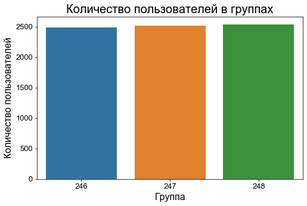

```python
users_by_exp = new_logs.groupby('exp_id')['device_id'].nunique().reset_index()
plt.figure(figsize=(8, 5))
sns.barplot(x='exp_id', y='device_id', data=users_by_exp)
sns.set_style("whitegrid")
plt.title('Количество пользователей в группах', fontsize=20)
plt.tick_params(labelsize=13)
plt.ylabel('Количество пользователей',fontsize=16)
plt.xlabel('Группа',fontsize=16)
plt.show()
```

В группах по 2500 пользователй, с небольшой разницей

### Есть 2 контрольные группы для А/А-эксперимента, чтобы проверить корректность всех механизмов и расчётов.

Проверьте, находят ли статистические критерии разницу между выборками 246 и 247.

Нужно создать таблицу для исследования воронки:

```python
pivot_logs = new_logs[new_logs['event_name']!='Tutorial'].pivot_table(index='event_name', columns='exp_id', values='device_id', aggfunc='nunique').sort_values('246', ascending=False)
pivot_logs
```

| exp_id event_name | 246 | 247 | 248 |
| --- | --- | --- | --- |
| MainScreenAppear | 2450 | 2476 | 2493 |
| OffersScreenAppear | 1542 | 1520 | 1531 |
| CartScreenAppear | 1266 | 1238 | 1230 |
| PaymentScreenSuccessful | 1200 | 1158 | 1181 |

```python
events_names = pivot_logs.index

alpha = 0.05

row1 = np.array([pivot_logs.loc[events_names[0], '246'], pivot_logs.loc[events_names[0], '247']]) # первое событие воронки
row2 = np.array([pivot_logs.loc[events_names[3], '246'], pivot_logs.loc[events_names[3], '247']]) # последнее событие воронки

p1 = row2[0] / row1[0]
p2 = row2[1] / row1[1]

p_combined = (row2[0] + row2[1]) / (row1[0] + row1[1])

difference = p1 - p2

z_value = difference / mth.sqrt(p_combined * (1 - p_combined) * (1/row1[0] + 1/row1[1]))

distr = st.norm(0, 1)

p_value = (1 - distr.cdf(abs(z_value))) * 2

print('p-значение: ', p_value)

if (p_value < alpha):
    print("Отвергаем нулевую гипотезу: между долями есть значимая разница")
else:
    print("Не получилось отвергнуть нулевую гипотезу, нет оснований считать доли разными")
```

```
p-значение:  0.12044299485641763
Не получилось отвергнуть нулевую гипотезу, нет оснований считать доли разными
```

```python
print('Разница между количеством пользователей на первом шаге воронки', round(((1 - (pivot_logs['246'][0] / pivot_logs['247'][0]))*100),2),'%')
```

```
Разница между количеством пользователей на первом шаге воронки 1.05 %
```

Здесь я проверил разницу между первым и последним событием в группах А и А - её нет, всё хорошо. Разница между группами по количеству пользователей лишь незначительно привышает 1%, будем считать это погрешностью. Контрольную группу А считаем пригодной

### Выберите самое популярное событие.

Посчитайте число пользователей, совершивших это событие в каждой из контрольных групп. Посчитайте долю пользователей, совершивших это событие. Проверьте, будет ли отличие между группами статистически достоверным. Проделайте то же самое для всех других событий (удобно обернуть проверку в отдельную функцию). Можно ли сказать, что разбиение на группы работает корректно?

Гипотеза: Доли по каждому событию в группах А1 и А2 отличаеются.

H нулевая - статистически значимых отличий не обнаружено

H первая - есть статистически значимые различия в долях

```python
def statistical_significance (data, group_1, group_2):

    events_names = data.index

    for i in range(1, 4): # у нас только 4 шага в воронке, обучение не берем

        alpha = 0.05

        row1 = np.array([data.loc[events_names[i-1], group_1], data.loc[events_names[i-1], group_2]])
        row2 = np.array([data.loc[events_names[i], group_1], data.loc[events_names[i], group_2]])

        p1 = row2[0] / row1[0]
        p2 = row2[1] / row1[1]

        p_combined = (row2[0] + row2[1]) / (row1[0] + row1[1])

        difference = p1 - p2

        z_value = difference / mth.sqrt(p_combined * (1 - p_combined) * (1/row1[0] + 1/row1[1]))

        distr = st.norm(0, 1)

        p_value = (1 - distr.cdf(abs(z_value))) * 2

        print('p-значение: ', p_value)

        if (p_value < alpha):
            print("Отвергаем нулевую гипотезу: между долями есть значимая разница")
        else:
            print("Не получилось отвергнуть нулевую гипотезу, нет оснований считать доли разными")

statistical_significance(pivot_logs, '246', '247')
```

```
p-значение:  0.2622344959255778
Не получилось отвергнуть нулевую гипотезу, нет оснований считать доли разными
p-значение:  0.6393754713145263
Не получилось отвергнуть нулевую гипотезу, нет оснований считать доли разными
p-значение:  0.18243439408067652
Не получилось отвергнуть нулевую гипотезу, нет оснований считать доли разными
```

Разбиение на группы работает хорошо, между двумя группами А1 и А2 - разницы со стратистической значимостью НЕТ.

### Аналогично поступите с группой с изменённым шрифтом.

```python
statistical_significance(pivot_logs, '246', '248')
```

```
p-значение:  0.2684281587249231
Не получилось отвергнуть нулевую гипотезу, нет оснований считать доли разными
p-значение:  0.2112170818054686
Не получилось отвергнуть нулевую гипотезу, нет оснований считать доли разными
p-значение:  0.14295341270419004
Не получилось отвергнуть нулевую гипотезу, нет оснований считать доли разными
```

```python
statistical_significance(pivot_logs, '247', '248')
```

```
p-значение:  0.9869365252844515
Не получилось отвергнуть нулевую гипотезу, нет оснований считать доли разными
p-значение:  0.4364903513062255
Не получилось отвергнуть нулевую гипотезу, нет оснований считать доли разными
p-значение:  0.005677465395736325
Отвергаем нулевую гипотезу: между долями есть значимая разница
```

### Какой уровень значимости вы выбрали при проверке статистических гипотез выше?

Посчитайте, сколько проверок статистических гипотез вы сделали. При уровне значимости 0.1 каждый десятый раз можно получать ложный результат. Какой уровень значимости стоит применить? Если вы хотите изменить его, проделайте предыдущие пункты и проверьте свои выводы.

```python
def statistical_significance2 (data, group_1, group_2):

    events_names = data.index

    for i in range(1, 4): # у нас только 4 шага в воронке, обучение не берем

        alpha = 0.01

        row1 = np.array([data.loc[events_names[i-1], group_1], data.loc[events_names[i-1], group_2]])
        row2 = np.array([data.loc[events_names[i], group_1], data.loc[events_names[i], group_2]])

        p1 = row2[0] / row1[0]
        p2 = row2[1] / row1[1]

        p_combined = (row2[0] + row2[1]) / (row1[0] + row1[1])

        difference = p1 - p2

        z_value = difference / mth.sqrt(p_combined * (1 - p_combined) * (1/row1[0] + 1/row1[1]))

        distr = st.norm(0, 1)

        p_value = (1 - distr.cdf(abs(z_value))) * 2

        print('p-значение: ', p_value)

        if (p_value < alpha):
            print("Отвергаем нулевую гипотезу: между долями есть значимая разница")
        else:
            print("Не получилось отвергнуть нулевую гипотезу, нет оснований считать доли разными")

statistical_significance2(pivot_logs, '246', '247')
```

```
p-значение:  0.2622344959255778
Не получилось отвергнуть нулевую гипотезу, нет оснований считать доли разными
p-значение:  0.6393754713145263
Не получилось отвергнуть нулевую гипотезу, нет оснований считать доли разными
p-значение:  0.18243439408067652
Не получилось отвергнуть нулевую гипотезу, нет оснований считать доли разными
```

```python
statistical_significance2(pivot_logs, '246', '248')
```

```
p-значение:  0.2684281587249231
Не получилось отвергнуть нулевую гипотезу, нет оснований считать доли разными
p-значение:  0.2112170818054686
Не получилось отвергнуть нулевую гипотезу, нет оснований считать доли разными
p-значение:  0.14295341270419004
Не получилось отвергнуть нулевую гипотезу, нет оснований считать доли разными
```

```python
statistical_significance2(pivot_logs, '247', '248')
```

```
p-значение:  0.9869365252844515
Не получилось отвергнуть нулевую гипотезу, нет оснований считать доли разными
p-значение:  0.4364903513062255
Не получилось отвергнуть нулевую гипотезу, нет оснований считать доли разными
p-значение:  0.005677465395736325
Отвергаем нулевую гипотезу: между долями есть значимая разница
```

## Шаг 6. Вывод

На практике я бы всё таки принял вариант 'B' (с измененным шрифтом) как дающий шанс на положительное изменение в конверсии, хоть и незначительное, на грани статистической значимости. Уже при альфа = 0,5% статистической значимости выявлено не будет.